# Laboratory 02

Carmen Martín Turrero

Date : 31/03/2022

```r
library(ggplot2)
library(GoFKernel)
library(latex2exp)
```

## Exercise 1

A set of measurements have been performed on the concentration of a contaminant in tap water. The following tables reports a set of values (x), with the corresponding probabilities given by the two methods (p1 and p2).

```r
x = c(15.58, 15.9, 16, 16.1, 16.2)
p1 = c(0.15, 0.21, 0.35, 0.15, 0.14)
p2 = c(0.14, 0.05, 0.64, 0.08, 0.09)
```

Evaluate the expected values, E[X], and the variance, Var(X), for both methods.

```r
# First method
E1 <- sum(x*p1)
var1 <- sum(x**2*p1) - E1**2

message('First method: E[x] = ', round(E1,3), ', Variance = ', round(var1,3))
```

```
First method: E[x] = 15.959, Variance = 0.034
```

```r
#Second method
E2 <- sum(x*p2)
var2 <- sum(x**2*p2) - E2**2
message('Second method: E[x] = ', round(E2, 3), ', Variance = ', round(var2, 3))
```

```
Second method: E[x] = 15.962, Variance = 0.028
```

## Exercise 2

The waiting time, in minutes, at the doctor’s is about 30 minutes, and the distribution follows an exponential pdf with rate 1/30.

2.1. Simulate the waiting time for 50 people at the doctor’s office and plot the relative histogram.

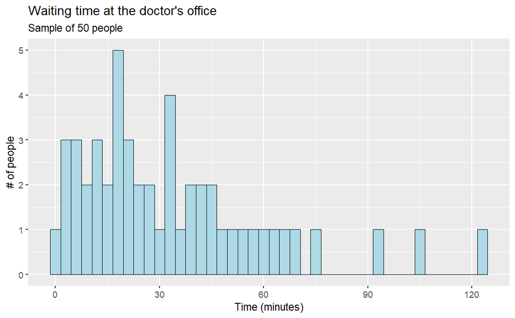

```r
w.time <- 30 #minutes
lambda <- 1/30

# Sampling from the distribution
sampl <- rexp(50, rate = lambda)
S <- data.frame(sampl)

g <- ggplot(S, aes(sampl))

g + geom_histogram(binwidth = 3,
                   fill = "lightblue",
                   col="black",
                   size=.2) +
  scale_x_continuous(breaks = seq(0, 210, 30)) +
  labs(title="Waiting time at the doctor's office",
       subtitle="Sample of 50 people",
       x = "Time (minutes)", y = "# of people")
```

2.2. What is the probability that a person will wait for less than 10 minutes?

```r
#Using the CDF
cat("P(X<10) = ", pexp(10, lambda))
```

```
P(X<10) =  0.2834687
```

2.3. Evaluate the average waiting time from the simulated data and compare it with the expected value.

```r
av.wait <- mean(sampl)

cat("The average waiting time derived from the sampling of the distributions is", round(av.wait,2), "minutes, while the expected value is of 30 minutes.")
```

```
The average waiting time derived from the sampling of the distributions is 33.65 minutes, while the expected value is of 30 minutes.
```

2.4. What is the probability for waiting more than one hour before being received?

```r
#Using the CDF
cat("P(X>60) = ", 1 - pexp(60, lambda))
```

```
P(X>60) =  0.1353353
```

## Exercise 3

Let’s suppose that on a book, on average, there is one typo error every three pages. If the number of errors follows a Poisson distribution, plot the pdf and cdf, and calculate the probability that there is at least one error on a specific page of the book.

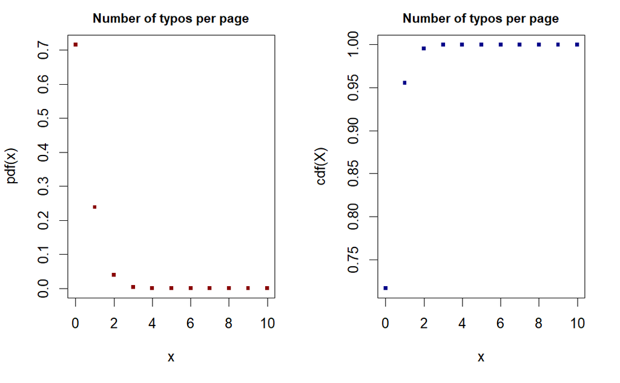

```r
# lambda
av.typo <- 1/3

# Distributions
typo.pdf <- dpois(0:10, lambda = av.typo)
typo.cdf <- ppois(0:10, lambda = av.typo)

# Plot
options(repr.plot.width=14, repr.plot.height=6)  #to set graph size
par(mfrow=c(1,2))
plot(x = 0:10, y = typo.pdf, lwd=2.5, pch=15, cex = 0.6, col="darkred",
     main="Number of typos per page", cex.main=0.9,
     xlab="x", ylab="pdf(x)", cex.lab=1)

plot(x = 0:10, y = typo.cdf, lwd=2.5, pch=15, cex = 0.6, col="darkblue",
     main="Number of typos per page", cex.main=0.9,
     xlab="x", ylab="cdf(X)", cex.lab=1)
```

```r
# At least one error in a specific page
cat("Probability of finding at least one error on a specific page:", 1 - typo.cdf[1])
```

```
Probability of finding at least one error on a specific page: 0.2834687
```

## Exercise 4

We randomly draw cards from a deck of 52 cards, with replacement, until one ace is drawn. Calculate the probability that at least 10 draws are needed.

```r
# The probability of drawing an ace from the deck is 4/52:
p.ace <- 1/13

# Using a geometric distribution we obtain the probability of not picking an ace in the first 9 trials and use normalization to get the probability of needing at least 10 draws
ace.cdf <- pgeom(1:10, prob = p.ace)
message("Probability of needing at least 10 draws:", round(1-ace.cdf[9],3))
```

```
Probability of needing at least 10 draws:0.449
```

## Exercise 5

The time it takes a student to complete a TOLC-I University orientation and evaluation test follows a density function of the form below, where t is the time in hours.

$$\begin{equation}
f(t)=
\begin{cases}
c(t-1)(2-t) & 1<t<2\\
0 & \text{otherwise}
\end{cases}
\end{equation}$$

5.1. Using the integrate() R function, determine the constant c (and verify it analytically).

```r
# The integral over the density function must be 1. Therefore, the constant c is given by
integral <- integrate(function(t){(t-1)*(2-t)}, lower=1, upper=2)
c <- 1/integral$value

message("c = ",c)
```

```
c = 6
```

Lets prove the result analytically:

The integral of the function is 0 if evaluated outside (1,2). Therefore, we obtain:

$$\begin{equation}
F(t) = \int_{0}^{\infty} f(t) dt = \int_1^2 c(t-1)(2-t) dt = c \int_1^2
(-t^2+3t-2) dt
\end{equation}$$

By solving the integral
$$\begin{equation}
c \int_1^2 (-t^2+3t-2) dt = -c·\frac{2t^3 - 9t^2 +12t}{6}\Biggr|_{1}^2 =
\frac{c}{6}
\end{equation}$$

And, knowing that the integral must be equal to 1, we get the result of c = 6, which matches the one obtained using the integrate() function.

5.2. Write the set of four R functions and plot the pdf and cdf, respectively.

```r
# The four functions are: PDF, CDF, quantile function and sampling from distribution.

# Probability density function
d.exam <- function(t) {
  if (1<t & t<2) pdf <- 6*(t-1)*(2-t)
  else pdf <- 0
  return (pdf)
}
# So we can apply it to vectors value by value:
d.exam <- Vectorize(d.exam)

# Cumulative density function
# CDF is the integral of the pdf
p.exam <- function(t) {
  return(integrate(d.exam, lower=0, upper=t)$value)
}
p.exam <- Vectorize(p.exam)

# Quantile function
# The quantile function is the inverse of the CDF, we use 'inverse' from GoFKernel library, which is specifically designed to perform the inverse transform of a CDF
q.exam <- inverse(p.exam, 1, 2)
q.exam <- Vectorize(q.exam)

# Sampling from distribution
r.exam <- function(N, cdf, a, b) {
    sampl <- runif(N)
    #invert the CDF in the interval (a, b)
    rf <- Vectorize(inverse(cdf, a, b))
    return (rf(sampl))
}
```

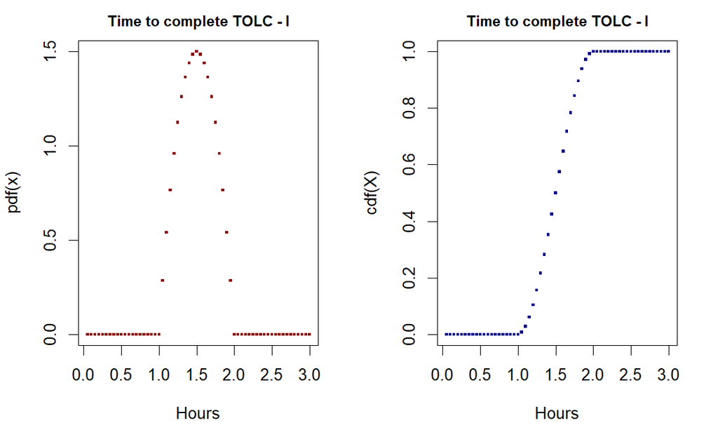

```r
# Plot PDF and CDF
x <- seq(0.05, 3, 0.05)

options(repr.plot.width=14, repr.plot.height=6)  #to set graph size
par(mfrow=c(1,2))

plot(x = x, y = d.exam(x), lwd=2.5, pch=15, cex = 0.4, col="darkred",
     main="Time to complete TOLC - I", cex.main=0.9,
     xlab="Hours", ylab="pdf(x)", cex.lab=1)

plot(x =x, y = p.exam(x), lwd=2.5, pch=15, cex = 0.4, col="darkblue",
     main="Time to complete TOLC - I", cex.main=0.9,
     xlab="Hours", ylab="cdf(X)", cex.lab=1)
```

5.3. Evaluate the probability that the student will finish the aptitude test in more than 75 minutes. And that it will take between 90 and 120 minutes.

```r
# We need to convert from minutes to hours, therefore:
message("P(t>(75min)) = ", round(1 - p.exam(75/60),4))
```

```
P(t>(75min)) = 0.8437
```

```r
message("P((90min)<t<(120min)) = ", p.exam(120/60) - p.exam(90/60))
```

```
P((90min)<t<(120min)) = 0.5
```

## Exercise 6

The lifetime of tires sold by an used tires shop is $10^4 x$ km, where $x$ is a random variable following the distribution function below

$$\begin{equation}
f(t)=
\begin{cases}
\frac{2}{x^2} & 1<t<2\\
0 & \text{otherwise}
\end{cases}
\end{equation}$$

6.1. Write the set of four R functions and plot the pdf and cdf, respectively.

```r
# Lifetime of tires
tire.lf <- function(x){10**4*x} #x in kilometers

# x follows the distribution described by:
# Probability density function
d.tires <- function(x) {
  if (1<x & x<2) pdf <- 2/(x**2)
  else pdf <- 0
  return (pdf)
}
d.tires <- Vectorize(d.tires)

# Cumulative density function
# CDF is the integral of the pdf
p.tires <- function(x) {
  return(integrate(d.tires, lower=0, upper=x)$value)
}
p.tires <- Vectorize(p.tires)

# Quantile function
# The quantile function is the inverse of the CDF, we use 'inverse' from GoFKernel library, which is specifically designed to perform the inverse transform of a CDF
q.tires <- inverse(p.tires, 1, 2)
q.tires <- Vectorize(q.tires)

# Sampling from distribution
r.tires <- function(N, cdf, a, b) {
    sampl <- runif(N)
    #invert the CDF in the interval (a, b)
    rf <- Vectorize(inverse(cdf, a, b))
    return (rf(sampl))
}
```

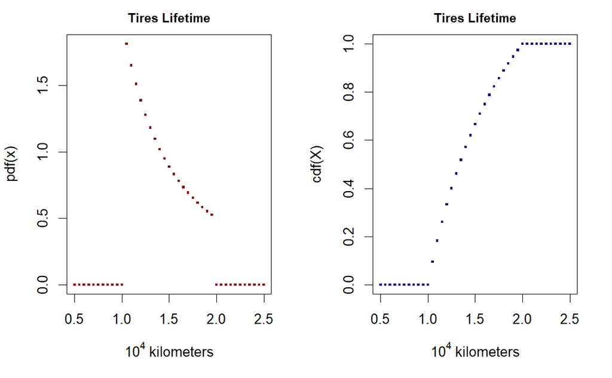

```r
# Plot PDF and CDF

# We have to adjust the kilometers to our scale
x <- seq(5000/10000,25000/10000, 0.05)

options(repr.plot.width=14, repr.plot.height=6)  #to set graph size
par(mfrow=c(1,2))

plot(x = x, y = d.tires(x), lwd=2.5, pch=15, cex = 0.4, col="darkred",
     main="Tires Lifetime", cex.main=0.9,
     xlab=TeX(r'($10^4$ kilometers)'), ylab="pdf(x)", cex.lab=1)

plot(x =x, y = p.tires(x), lwd=2.5, pch=15, cex = 0.4, col="darkblue",
     main="Tires Lifetime", cex.main=0.9,
     xlab=TeX(r'($10^4$ kilometers)'), ylab="cdf(X)", cex.lab=1)
```

6.2. Determine the probability that tires will last less than 15000 km.

```r
# We need to convert to the appropriate scale and use CDF, therefore:
message("P(t<(15000 km)) = ", round(p.tires(15000/10000),4))
```

```
P(t<(15000 km)) = 0.6667
```

6.3. Sample 3000 random variables from the distribution and determine the mean value and the variance, using the expression $Var(X) = E[X^2] − E[X]^2$.

```r
# We sample in the interval 5000km - 25000km
samples <- r.tires(3000, p.tires,5000/10000,25000/10000)
```

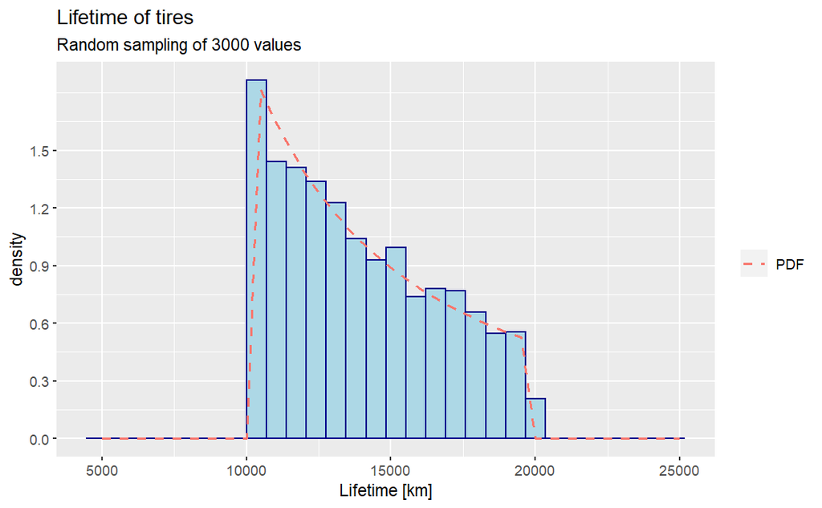

```r
# Plot to see the distribution of the sampling compared to the PDF
# In order to plot with ggplot we need to create a dataframe with the data
pdf <- d.tires(x)
samples.df <- data.frame(lifetime = samples)
pdf.df <- data.frame(x, pdf)

# Plot
r_hist <- ggplot() +
  geom_histogram(data = samples.df, aes(x=lifetime, y=..density..), color="darkblue", fill="lightblue", size = 0.5) +
  geom_line(data =pdf.df, aes(x=x, y=pdf, color = "PDF"), linetype =2 , size = 0.8) +
  labs(title = "Lifetime of tires", subtitle = "Random sampling of 3000 values") +
  scale_x_continuous(name= "Lifetime [km]", breaks = seq(0, 2.5, 0.5), labels = function(x){x*(10**4)}) +
  scale_y_continuous(breaks=seq(0, 1.5, 0.3)) +
  guides(color=guide_legend(NULL, order = 5))

r_hist
```

```r
# Using the mean R function
av.lifetime <- mean(samples)
var.lifetime <- (mean(samples**2) - av.lifetime**2)

message('Expected value: ', round(av.lifetime*10**4), 'km\n',
        'Variance: ', round(var.lifetime*10**4), 'km')
```

```
Expected value: 13927km
Variance: 771km
```